# Machine Learning Engineer Nanodegree

## Project: Build a Digit Recognition Program

In this notebook, a template is provided for you to implement your functionality in stages which is required to successfully complete this project. If additional code is required that cannot be included in the notebook, be sure that the Python code is successfully imported and included in your submission, if necessary. Sections that begin with **'Implementation'** in the header indicate where you should begin your implementation for your project. Note that some sections of implementation are optional, and will be marked with **'Optional'** in the header.

In addition to implementing code, there will be questions that you must answer which relate to the project and your implementation. Each section where you will answer a question is preceded by a **'Question'** header. Carefully read each question and provide thorough answers in the following text boxes that begin with **'Answer:'**. Your project submission will be evaluated based on your answers to each of the questions and the implementation you provide.

> **Note:** Code and Markdown cells can be executed using the **Shift + Enter** keyboard shortcut. In addition, Markdown cells can be edited by typically double-clicking the cell to enter edit mode.

## Step 1: Design and Test a Model Architecture

Design and implement a deep learning model that learns to recognize sequences of digits. Train the model using synthetic data generated by concatenating character images from [notMNIST](http://yaroslavvb.blogspot.com/2011/09/notmnist-dataset.html) or [MNIST](http://yann.lecun.com/exdb/mnist/). To produce a synthetic sequence of digits for testing, you can for example limit yourself to sequences up to five digits, and use five classifiers on top of your deep network. You would have to incorporate an additional ‘blank’ character to account for shorter number sequences.

There are various aspects to consider when thinking about this problem:

- Your model can be derived from a deep neural net or a convolutional network.
- You could experiment sharing or not the weights between the softmax classifiers.
- You can also use a recurrent network in your deep neural net to replace the classification layers and directly emit the sequence of digits one-at-a-time.

Here is an example of a [published baseline model on this problem](http://static.googleusercontent.com/media/research.google.com/en//pubs/archive/42241.pdf). ([video](https://www.youtube.com/watch?v=vGPI_JvLoN0))

### Implementation

Use the code cell (or multiple code cells, if necessary) to implement the first step of your project. Once you have completed your implementation and are satisfied with the results, be sure to thoroughly answer the questions that follow.

```python
### Your code implementation goes here.
### Feel free to use as many code cells as needed.
# These are all the modules we'll be using later. Make sure you can import them
# before proceeding further.
from __future__ import print_function
import matplotlib.pyplot as plt
import numpy as np
#import os
#import sys
#import tarfile
from IPython.display import display, Image
from scipy import ndimage
#from sklearn.linear_model import LogisticRegression
#from six.moves.urllib.request import urlretrieve
from six.moves import cPickle as pickle
import tensorflow as tf
from tensorflow.python.ops import rnn, rnn_cell
#from tempfile import TemporaryFile
```

First, we'll download the dataset to our local machine. The data consists of characters rendered in a variety of fonts on a 28x28 image. The labels are limited to 'A' through 'J' (10 classes). The training set has about 500k and the testset 19000 labelled examples. Given these sizes, it should be possible to train models quickly on any machine.

```python
url = 'http://yaroslavvb.com/upload/notMNIST/'

def maybe_download(filename, expected_bytes, force=False):
  """Download a file if not present, and make sure it's the right size."""
  if force or not os.path.exists(filename):
    filename, _ = urlretrieve(url + filename, filename)
  statinfo = os.stat(filename)
  if statinfo.st_size == expected_bytes:
    print('Found and verified', filename)
  else:
    raise Exception(
      'Failed to verify' + filename + '. Can you get to it with a browser?')
  return filename

train_filename = maybe_download('notMNIST_large.tar.gz', 247336696)
test_filename = maybe_download('notMNIST_small.tar.gz', 8458043)
```

```
Found and verified notMNIST_large.tar.gz
Found and verified notMNIST_small.tar.gz
```

Extract the dataset from the compressed .tar.gz file. This should give you a set of directories, labelled A through J.

```python
num_classes = 10
np.random.seed(133)

def maybe_extract(filename, force=False):
  root = os.path.splitext(os.path.splitext(filename)[0])[0]  # remove .tar.gz
  if os.path.isdir(root) and not force:
    # You may override by setting force=True.
    print('%s already present - Skipping extraction of %s.' % (root, filename))
  else:
    print('Extracting data for %s. This may take a while. Please wait.' % root)
    tar = tarfile.open(filename)
    sys.stdout.flush()
    tar.extractall()
    tar.close()
  data_folders = [
    os.path.join(root, d) for d in sorted(os.listdir(root))
    if os.path.isdir(os.path.join(root, d))]
  if len(data_folders) != num_classes:
    raise Exception(
      'Expected %d folders, one per class. Found %d instead.' % (
        num_classes, len(data_folders)))
  print(data_folders)
  return data_folders

train_folders = maybe_extract(train_filename)
test_folders = maybe_extract(test_filename)
```

Now let's load the data in a more manageable format. Since, depending on your computer setup you might not be able to fit it all in memory, we'll load each class into a separate dataset, store them on disk and curate them independently. Later we'll merge them into a single dataset of manageable size.

We'll convert the entire dataset into a 3D array (image index, x, y) of floating point values, normalized to have approximately zero mean and standard deviation ~0.5 to make training easier down the road.

A few images might not be readable, we'll just skip them.

```python
image_size = 28  # Pixel width and height.
pixel_depth = 255.0  # Number of levels per pixel.

def load_letter(folder, min_num_images):
  """Load the data for a single letter label."""
  image_files = os.listdir(folder)
  dataset = np.ndarray(shape=(len(image_files), image_size, image_size),
                         dtype=np.float32)
  image_index = 0
  print(folder)
  for image in os.listdir(folder):
    image_file = os.path.join(folder, image)
    try:
      image_data = (ndimage.imread(image_file).astype(float) -
                    pixel_depth / 2) / pixel_depth
      if image_data.shape != (image_size, image_size):
        raise Exception('Unexpected image shape: %s' % str(image_data.shape))
      dataset[image_index, :, :] = image_data
      image_index += 1
    except IOError as e:
      print('Could not read:', image_file, ':', e, '- it\'s ok, skipping.')

  num_images = image_index
  dataset = dataset[0:num_images, :, :]
  if num_images < min_num_images:
    raise Exception('Many fewer images than expected: %d < %d' %
                    (num_images, min_num_images))

  print('Full dataset tensor:', dataset.shape)
  print('Mean:', np.mean(dataset))
  print('Standard deviation:', np.std(dataset))
  return dataset

def maybe_pickle(data_folders, min_num_images_per_class, force=False):
  dataset_names = []
  for folder in data_folders:
    set_filename = folder + '.pickle'
    dataset_names.append(set_filename)
    if os.path.exists(set_filename) and not force:
      # You may override by setting force=True.
      print('%s already present - Skipping pickling.' % set_filename)
    else:
      print('Pickling %s.' % set_filename)
      dataset = load_letter(folder, min_num_images_per_class)
      try:
        with open(set_filename, 'wb') as f:
          pickle.dump(dataset, f, pickle.HIGHEST_PROTOCOL)
      except Exception as e:
        print('Unable to save data to', set_filename, ':', e)

  return dataset_names

train_datasets = maybe_pickle(train_folders, 45000)
test_datasets = maybe_pickle(test_folders, 18)
```

Merge and prune the training data as needed. Depending on your computer setup, you might not be able to fit it all in memory, and you can tune `train_size` as needed. The labels will be stored into a separate array of integers 0 through 9.

Also create a validation dataset for hyperparameter tuning.

```python
def make_arrays(nb_rows, img_size):
  if nb_rows:
    dataset = np.ndarray((nb_rows, img_size, img_size), dtype=np.float32)
    labels = np.ndarray(nb_rows, dtype=np.int32)
  else:
    dataset, labels = None, None
  return dataset, labels

def merge_datasets(pickle_files, train_size, valid_size=0):
  num_classes = len(pickle_files)
  valid_dataset, valid_labels = make_arrays(valid_size, image_size)
  train_dataset, train_labels = make_arrays(train_size, image_size)
  vsize_per_class = valid_size // num_classes
  tsize_per_class = train_size // num_classes

  start_v, start_t = 0, 0
  end_v, end_t = vsize_per_class, tsize_per_class
  end_l = vsize_per_class+tsize_per_class
  for label, pickle_file in enumerate(pickle_files):
    try:
      with open(pickle_file, 'rb') as f:
        letter_set = pickle.load(f)
        # let's shuffle the letters to have random validation and training set
        np.random.shuffle(letter_set)
        if valid_dataset is not None:
          valid_letter = letter_set[:vsize_per_class, :, :]
          valid_dataset[start_v:end_v, :, :] = valid_letter
          valid_labels[start_v:end_v] = label
          start_v += vsize_per_class
          end_v += vsize_per_class

        train_letter = letter_set[vsize_per_class:end_l, :, :]
        train_dataset[start_t:end_t, :, :] = train_letter
        train_labels[start_t:end_t] = label
        start_t += tsize_per_class
        end_t += tsize_per_class
    except Exception as e:
      print('Unable to process data from', pickle_file, ':', e)
      raise

  return valid_dataset, valid_labels, train_dataset, train_labels


train_size = 200000
valid_size = 10000
test_size = 10000

valid_dataset, valid_labels, train_dataset, train_labels = merge_datasets(
  train_datasets, train_size, valid_size)
_, _, test_dataset, test_labels = merge_datasets(test_datasets, test_size)

print('Training:', train_dataset.shape, train_labels.shape)
print('Validation:', valid_dataset.shape, valid_labels.shape)
print('Testing:', test_dataset.shape, test_labels.shape)
```

Next, we'll randomize the data. It's important to have the labels well shuffled for the training and test distributions to match.

```python
def randomize(dataset, labels):
  permutation = np.random.permutation(labels.shape[0])
  shuffled_dataset = dataset[permutation,:,:]
  shuffled_labels = labels[permutation]
  return shuffled_dataset, shuffled_labels
train_dataset, train_labels = randomize(train_dataset, train_labels)
test_dataset, test_labels = randomize(test_dataset, test_labels)
valid_dataset, valid_labels = randomize(valid_dataset, valid_labels)
```

Finally, let's save the data for later reuse:

```python
pickle_file = 'notMNIST.pickle'

try:
  f = open(pickle_file, 'wb')
  save = {
    'train_dataset': train_dataset,
    'train_labels': train_labels,
    'valid_dataset': valid_dataset,
    'valid_labels': valid_labels,
    'test_dataset': test_dataset,
    'test_labels': test_labels,
    }
  pickle.dump(save, f, pickle.HIGHEST_PROTOCOL)
  f.close()
except Exception as e:
  print('Unable to save data to', pickle_file, ':', e)
  raise
```

```python
statinfo = os.stat(pickle_file)
print('Compressed pickle size:', statinfo.st_size)
```

First reload the data we generated above.

```python
pickle_file = 'notMNIST.pickle'

with open(pickle_file, 'rb') as f:
  save = pickle.load(f)
  train_dataset = save['train_dataset']
  train_labels = save['train_labels']
  valid_dataset = save['valid_dataset']
  valid_labels = save['valid_labels']
  test_dataset = save['test_dataset']
  test_labels = save['test_labels']
  del save  # hint to help gc free up memory
  print('Training set', train_dataset.shape, train_labels.shape)
  print('Validation set', valid_dataset.shape, valid_labels.shape)
  print('Test set', test_dataset.shape, test_labels.shape)
```

```
Training set (200000, 28, 28) (200000,)
Validation set (10000, 28, 28) (10000,)
Test set (10000, 28, 28) (10000,)
```

```python
%matplotlib inline
def showDataImages(dataset,n): # shows size of the sample

   # indices=np.random.choice(dataset.shape[0], n)
    fig=plt.figure()
    for i in range(n):
        a=fig.add_subplot(1,n,i+1)
        plt.imshow(dataset[i,:,:])
        # a.set_title(chr(labels[indices[i]]+ord('A')))
        a.axes.get_xaxis().set_visible(False)
        a.axes.get_yaxis().set_visible(False)
    plt.show()
```

Concatenate sequences of five digits.

[figure not shown]

[figure not shown]

[figure not shown]

```python
image_size = 28

def concat(dataset, nb_rows):
    catset = np.ndarray(shape=(nb_rows, image_size, 5*image_size),
                         dtype=np.float32)
    for j in xrange(nb_rows):
        image = np.concatenate(dataset[5*j:5*(j+1),:,:], axis=1)

        catset[j,:,:] = image


    showDataImages(catset, 2)
    return catset

train_catset = concat(train_dataset, 40000)
valid_catset = concat(valid_dataset, 2000)
test_catset = concat(test_dataset, 2000)
showDataImages(test_catset, 5)
```

save above files and label files for reuse

```python
catsets = [train_catset, valid_catset, test_catset]
labels = [train_labels, valid_labels, test_labels]
with open('cats.pkl', 'wb') as outfile1:
    pickle.dump(catsets, outfile1, pickle.HIGHEST_PROTOCOL)

with open('labs.pkl', 'wb') as outfile2:
    pickle.dump(labels, outfile2, pickle.HIGHEST_PROTOCOL)
```

```
(40000, 28, 140) (2000, 28, 140) (2000, 28, 140)
(200000,) (10000,) (10000,)
```

[figure not shown]

[figure not shown]

[figure not shown]

```python
with open('cats.pkl', 'rb') as infile1:
    result1 = pickle.load(infile1)

train_catset = result1[0]
valid_catset = result1[1]
test_catset = result1[2]
print(train_catset.shape, valid_catset.shape, test_catset.shape)

with open('labs.pkl', 'rb') as infile2:
    result2 = pickle.load(infile2)

train_labels = result2[0]
valid_labels = result2[1]
test_labels = result2[2]
print(train_labels.shape, valid_labels.shape, test_labels.shape)

showDataImages(train_catset, 2)
showDataImages(valid_catset, 2)
showDataImages(test_catset, 2)
```

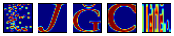

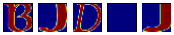

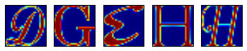

```python
#reverse concatenate to make independent digits
l_sequence = 5
image_size = 28

def rev_concat(catset):
    nb_rows = catset.shape[0]*l_sequence
    dataset = np.ndarray(shape=(nb_rows, image_size, image_size),
                         dtype=np.float32)




    data = np.split(catset, l_sequence, axis=2)

    for j in xrange(nb_rows/l_sequence):
        dataset[5*j:5*(j+1),:,:] = [data[i][j,:,:] for i in range(len(data))]

    showDataImages(dataset, 5)

    return dataset

train_dataset = rev_concat(train_catset)
valid_dataset = rev_concat(valid_catset)
test_dataset = rev_concat(test_catset)
```

```python
datasets = [train_dataset, valid_dataset, test_dataset]

with open('data.pkl', 'wb') as outfile3:
    pickle.dump(datasets, outfile3, pickle.HIGHEST_PROTOCOL)
```

```
(200000, 28, 28) (10000, 28, 28) (10000, 28, 28)
(200000,) (10000,) (10000,)
```

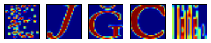

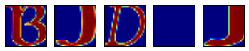

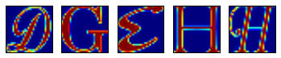

```python
with open('data.pkl', 'rb') as infile1:
    result1 = pickle.load(infile1)

train_dataset = result1[0]
valid_dataset = result1[1]
test_dataset = result1[2]
print(train_dataset.shape, valid_dataset.shape, test_dataset.shape)

with open('labs.pkl', 'rb') as infile2:
    result2 = pickle.load(infile2)

train_labels = result2[0]
valid_labels = result2[1]
test_labels = result2[2]
print(train_labels.shape, valid_labels.shape, test_labels.shape)

showDataImages(train_dataset, 5)
showDataImages(valid_dataset, 5)
showDataImages(test_dataset, 5)
```

```python
#concatenate labels
def concat_lab(labels, nb_rows):
    catlab = np.ndarray(shape=(nb_rows), dtype=(np.int32, (5,)))
    for j in xrange(nb_rows):
        label = labels[5*j:5*(j+1)]

        catlab[j] = label


    return catlab


train_catlabels = concat_lab(train_labels, 40000)
valid_catlabels = concat_lab(valid_labels, 2000)
test_catlabels = concat_lab(test_labels, 2000)
print(test_catlabels[:1])
```

```
[[3 6 4 7 7]]
```

Reformat into a shape that's more adapted to the models we're going to train:

- data as a flat matrix,
- labels as float 1-hot encodings.

```python
image_size = 28
num_labels = 10

def reformat(dataset, labels):
  dataset = dataset.reshape((-1, image_size * image_size)).astype(np.float32)
  # Map 2 to [0.0, 1.0, 0.0 ...], 3 to [0.0, 0.0, 1.0 ...]
  labels = (np.arange(num_labels) == labels[:,None]).astype(np.float32)
  return dataset, labels
train_dataset, train_labels = reformat(train_dataset, train_labels)
valid_dataset, valid_labels = reformat(valid_dataset, valid_labels)
test_dataset, test_labels = reformat(test_dataset, test_labels)
print('Training set', train_dataset.shape, train_labels.shape)
print('Validation set', valid_dataset.shape, valid_labels.shape)
print('Test set', test_dataset.shape, test_labels.shape)
```

```
Training set (200000, 784) (200000, 10)
Validation set (10000, 784) (10000, 10)
Test set (10000, 784) (10000, 10)
```

```python
def accuracy(predictions, labels):
  return (100.0 * np.sum(np.argmax(predictions, 1) == np.argmax(labels, 1))
          / predictions.shape[0])
def accuracy_seq(predictions, labels):
    a = 0
    s = predictions.shape[0]/5
    for i in range(s):
        a += ((np.sum(np.argmax(predictions[5*i:5*(i+1)], 1) == np.argmax(labels[5*i:5*(i+1)], 1)) >= 4.9))
    return 100.0 * a / s
```

```python
# Network Parameters
n_hidden_1 = 1024 # 1st layer num features
n_hidden_2 = 512 # 2nd layer num features
n_input = 784 # MNIST data input (img shape: 28*28)
n_classes = 10 # MNIST total classes (0-9 digits)
batch_size = 100
p = 1e-5

graph = tf.Graph()
with graph.as_default():





    # tf Graph input
    tf_train_dataset = tf.placeholder(tf.float32, shape=(batch_size, n_input))
    tf_train_labels = tf.placeholder(tf.float32, shape=(batch_size, n_classes))
    tf_valid_dataset = tf.constant(valid_dataset)
    tf_test_dataset = tf.constant(test_dataset)

    # Create model
    def multilayer_perceptron(_X, _weights, _biases):
        layer_1 = tf.nn.relu(tf.add(tf.matmul(_X, _weights['h1']), _biases['b1'])) #Hidden layer with RELU activation
        layer_2 = tf.nn.relu(tf.add(tf.matmul(layer_1, _weights['h2']), _biases['b2'])) #Hidden layer with RELU activation
        return tf.matmul(layer_2, _weights['out']) + _biases['out']

    # Store layers weight & bias
    weights = {
        'h1': tf.Variable(tf.truncated_normal([n_input, n_hidden_1], stddev = 0.05)),
        'h2': tf.Variable(tf.truncated_normal([n_hidden_1, n_hidden_2], stddev = 0.05)),
        'out': tf.Variable(tf.truncated_normal([n_hidden_2, n_classes], stddev = 0.05))
    }
    biases = {
        'b1': tf.Variable(tf.zeros([n_hidden_1])),
        'b2': tf.Variable(tf.zeros([n_hidden_2])),
        'out': tf.Variable(tf.zeros([n_classes]))
    }

    regularizer = np.multiply(p, tf.nn.l2_loss(weights['h1']))


    # Construct model
    pred = multilayer_perceptron(tf_train_dataset, weights, biases)

    # Define loss and optimizer
    loss = tf.reduce_mean(tf.nn.softmax_cross_entropy_with_logits(pred, tf_train_labels)) + regularizer# Softmax loss
    global_step = tf.Variable(0)  # count the number of steps taken.
    learning_rate = tf.train.exponential_decay(0.4, global_step, 1000, 0.65, staircase=True)
    optimizer = tf.train.GradientDescentOptimizer(learning_rate).minimize(loss, global_step=global_step)

     # Predictions for the training, validation, and test data.

    train_prediction = tf.nn.softmax(pred)
    valid_prediction = tf.nn.softmax(multilayer_perceptron (tf_valid_dataset, weights, biases))
    test_prediction = tf.nn.softmax(multilayer_perceptron(tf_test_dataset, weights, biases))
```

```python
num_steps = 2001

with tf.Session(graph=graph) as session:
  tf.initialize_all_variables().run()
  print("Initialized")
  for step in range(num_steps):
    # Pick an offset within the training data, which has been randomized.
    # Note: we could use better randomization across epochs.
    offset = (step * batch_size) % (train_labels.shape[0])
    # Generate a minibatch.
    batch_data = train_dataset[offset:(offset + batch_size), :]
    batch_labels = train_labels[offset:(offset + batch_size), :]
    # Prepare a dictionary telling the session where to feed the minibatch.
    # The key of the dictionary is the placeholder node of the graph to be fed,
    # and the value is the numpy array to feed to it.
    feed_dict = {tf_train_dataset : batch_data, tf_train_labels : batch_labels}
    _, l, predictions = session.run(
      [optimizer, loss, train_prediction], feed_dict=feed_dict)
    if (step % 100 == 0):
      print("Minibatch loss at step %d: %f" % (step, l))
      print("Minibatch accuracy: %.1f%%" % accuracy(predictions, batch_labels))
      print("Validation accuracy: %.1f%%" % accuracy(
        valid_prediction.eval(), valid_labels))
  print("Test accuracy: %.1f%%" % accuracy(test_prediction.eval(), test_labels))
  print("Test accuracy_seq: %.1f%%" % accuracy_seq(test_prediction.eval(), test_labels))
```

```
Initialized
Minibatch loss at step 0: 2.322126
Minibatch accuracy: 12.0%
Validation accuracy: 37.9%
Minibatch loss at step 100: 0.448200
Minibatch accuracy: 88.0%
Validation accuracy: 83.1%
Minibatch loss at step 200: 0.589237
Minibatch accuracy: 85.0%
Validation accuracy: 84.4%
Minibatch loss at step 300: 0.486624
Minibatch accuracy: 86.0%
Validation accuracy: 85.6%
Minibatch loss at step 400: 0.553234
Minibatch accuracy: 81.0%
Validation accuracy: 85.5%
Minibatch loss at step 500: 0.415395
Minibatch accuracy: 86.0%
Validation accuracy: 86.5%
Minibatch loss at step 600: 0.442423
Minibatch accuracy: 85.0%
Validation accuracy: 86.1%
Minibatch loss at step 700: 0.331659
Minibatch accuracy: 90.0%
Validation accuracy: 87.2%
Minibatch loss at step 800: 0.378212
Minibatch accuracy: 89.0%
Validation accuracy: 86.9%
Minibatch loss at step 900: 0.428086
Minibatch accuracy: 89.0%
Validation accuracy: 87.0%
Minibatch loss at step 1000: 0.450985
Minibatch accuracy: 86.0%
Validation accuracy: 87.6%
Minibatch loss at step 1100: 0.464603
Minibatch accuracy: 87.0%
Validation accuracy: 88.3%
Minibatch loss at step 1200: 0.404037
Minibatch accuracy: 89.0%
Validation accuracy: 88.2%
```

[output cut: 11 more lines]

```
Validation accuracy: 88.9%
Minibatch loss at step 1700: 0.383204
Minibatch accuracy: 89.0%
Validation accuracy: 89.1%
Minibatch loss at step 1800: 0.488967
Minibatch accuracy: 87.0%
Validation accuracy: 89.3%
Minibatch loss at step 1900: 0.465928
Minibatch accuracy: 85.0%
Validation accuracy: 89.6%
Minibatch loss at step 2000: 0.305284
Minibatch accuracy: 90.0%
Validation accuracy: 89.3%
Test accuracy: 94.5%
Test accuracy_seq: 75.2%
```

### Question 1

*What approach did you take in coming up with a solution to this problem?*

**Answer:** I started with a simple LSTM neural net which was an adaptation of https://github.com/aymericdamien/TensorFlow-Examples/ . I did not want to use a convolution net as described by the published baseline because my computer does not have a lot of memory, and the Deep Learning convnets seem to require that for good results. I concatenated sequences of five images from the notMIST dataset and then broke them apart before sending through the LSTM in batches of five so that the optimization and accuracy were done for the sequences of five. I adjusted various parameters, adding layers to the LSTM, changing the number of hidden layers, changing the batch size, and changing the learning rate. The learning rate was optimized at .001 and the batch size at 40. Changing the layers did not seem to affect the result. The accuracy for individual letters is good, ~.92 but requiring a perfect result for the 5 digits of a sequence to get a correct prediction is not as good, only ~.66. I then used my best model from the Deep Learning class, a relu perceptron with two hidden layers which improved the accuracy.

### Question 2

*What does your final architecture look like? (Type of model, layers, sizes, connectivity, etc.)*

**Answer:**My final model has two hidden relus of sizes 1024 and 512 as well as an l2-loss regularizer and an optimizer with learning rate decay.

### Question 3

*How did you train your model? How did you generate your synthetic dataset?* Include examples of images from the synthetic data you constructed.

**Answer:**I had 2000 training iterations with batches of 100 images from the concatenated sequences that were separated before sending through the neural net. I did not account for notMNIST images with bad labels that do not correspond to any letter which lowered my accuracy. The accuracy for individual letters is good, ~.94 but requiring a perfect result for the 5 digits of a sequence to get a correct prediction is not as good, only ~.75. The published baseline which achieves 96% accuracy on sequences had eight convolution hidden layers, far beyond the computing capacity of my PC. Below is a synthetic image: I would have difficulty identifying 2 of the letters below.

[figure not shown]

```python
showDataImages(train_catset, 1)
```

## Step 2: Train a Model on a Realistic Dataset

Once you have settled on a good architecture, you can train your model on real data. In particular, the [Street View House Numbers (SVHN)](http://ufldl.stanford.edu/housenumbers/) dataset is a good large-scale dataset collected from house numbers in Google Street View. Training on this more challenging dataset, where the digits are not neatly lined-up and have various skews, fonts and colors, likely means you have to do some hyperparameter exploration to perform well.

### Implementation

Use the code cell (or multiple code cells, if necessary) to implement the first step of your project. Once you have completed your implementation and are satisfied with the results, be sure to thoroughly answer the questions that follow.

```python
### Your code implementation goes here.
### Feel free to use as many code cells as needed.

# These are all the modules we'll be using later. Make sure you can import them
# before proceeding further.
from __future__ import print_function
import matplotlib.pyplot as plt
import numpy as np
import os
import sys
import tarfile
import scipy.io as sio

from IPython.display import display, Image
from scipy import ndimage, misc
#from sklearn.linear_model import LogisticRegression
from six.moves.urllib.request import urlretrieve
from six.moves import cPickle as pickle
import tensorflow as tf
from tensorflow.python.ops import rnn, rnn_cell
import h5py
import hdf5storage
#from tempfile import TemporaryFile
```

```python
url = 'http://ufldl.stanford.edu/housenumbers/'

extra_url = 'http://ufldl.stanford.edu/housenumbers/extra.tar.gz'

def maybe_download(filename, expected_bytes, force=False):
  """Download a file if not present, and make sure it's the right size."""
  if force or not os.path.exists(filename):
    filename, _ = urlretrieve(url + filename, filename)
  statinfo = os.stat(filename)
  if statinfo.st_size == expected_bytes:
    print('Found and verified', filename)
  else:
    raise Exception(
      'Failed to verify' + filename + '. Can you get to it with a browser?')
  return filename

train_filename = maybe_download('train.tar.gz', 404141560)
test_filename = maybe_download('test.tar.gz', 276555967)
```

```
Found and verified train.tar.gz
Found and verified test.tar.gz
```

```python
num_files = 2
np.random.seed(133)
def maybe_extract(filename, force=False):
  root = os.path.splitext(os.path.splitext(filename)[0])[0]  # remove .tar.gz

  if os.path.isdir(root) and not force:
    # You may override by setting force=True.
    print('%s already present - Skipping extraction of %s.' % (root, filename))
  else:
    print('Extracting data for %s. This may take a while. Please wait.' % root)
    tar = tarfile.open(filename)
    sys.stdout.flush()
    tar.extractall()
    tar.close()
  data_files = [
    os.path.join(root, f) for f in os.listdir(root)
   ]


  return data_files





train_file = maybe_extract(train_filename)
test_file = maybe_extract(test_filename)

print (len(train_file), len(test_file))

print(train_file[0])
if 'train/digitStruct.mat' in train_file:print(train_file.index('train/digitStruct.mat'))
if 'test/digitStruct.mat' in test_file:print(test_file.index('test/digitStruct.mat'))
print (train_file[1])
print(test_file[1])
```

```
train already present - Skipping extraction of train.tar.gz.
test already present - Skipping extraction of test.tar.gz.
33404 13070
train/22501.png
25454
9990
train/14884.png
test/9155.png
```

```python
f_train = train_file.pop(25454)
f_test = test_file.pop(9990)
if 'train/digitStruct.mat' in train_file:print(train_file.index('train/digitStruct.mat'))
if 'test/digitStruct.mat' in test_file:print(test_file.index('test/digitStruct.mat'))
```

```python
h5py_train = h5py.File(f_train)
h5py_test = h5py.File(f_test)
```

```python
#from Alexander Yau 12/21/16 Stack Overflow

def get_box_data(index, hdf5_data):
    """
    get `left, top, width, height` of each picture
    :param index:
    :param hdf5_data:
    :return:
    """
    meta_data = dict()
    meta_data['height'] = []
    meta_data['label'] = []
    meta_data['left'] = []
    meta_data['top'] = []
    meta_data['width'] = []


    def print_attrs(name, obj):
        vals = []

        if obj.shape[0] == 1:
            vals.append(obj[0][0])
        else:
            for k in range(obj.shape[0]):
                vals.append(int(hdf5_data[obj[k][0]][0][0]))

        meta_data[name] = vals


    box = hdf5_data['/digitStruct/bbox'][index]
    hdf5_data[box[0]].visititems(print_attrs)
    return meta_data

def get_name(index, hdf5_data):
    name = hdf5_data['/digitStruct/name']
    return ''.join([chr(v[0]) for v in hdf5_data[name[index][0]].value])


print(get_name(22500, h5py_train))
print(get_box_data(22500, h5py_train))
print(get_name(0, h5py_test))
print(get_box_data(0, h5py_test))
```

```
22501.png
{'width': [11, 8], 'top': [2, 1], 'label': [3, 1], 'left': [18, 29], 'height': [22, 22]}
1.png
{'width': [19.0], 'top': [7.0], 'label': [5.0], 'left': [43.0], 'height': [30.0]}
```

```python
Image('train/22501.png')
```

```python
Image('test/1.png')
```

```python
Image('train/252.png')
```

```python
#rescale axes to 32*32

zoom_im = ndimage.interpolation.zoom(crop_im, [1.45, 2.9])
print(zoom_im.shape)

misc.imsave('zoom.png', crop_im)
Image('zoom.png')
```

```
(32, 32)
```

```python
Image('train/22501.png')
imtest = ndimage.imread('train/22501.png')
print(imtest.shape)
```

```
(24, 52, 3)
```

```python
def get_image_digits(index, hdf5_data, t):

    digits = []
    labels = []
    name = t + get_name(index, hdf5_data)
    box_data = get_box_data(index, hdf5_data)
    k = len(box_data['top'])
    im = misc.imread(name, mode='P')
    for d in range(k):
        i, j = index + 1, d + 1
        s, t = str(i), str(j)
        n = s+'_'+t

        top = box_data['top'][d]
        height = box_data['height'][d]
        left = box_data['left'][d]
        width = box_data['width'][d]
        label = box_data['label'][d]
        bottom = top + height
        right = left + width
        labels.append(label)
        crop_dig = im[top:bottom, left:right]
        #print(crop_dig.shape)
        shape = crop_dig.shape
        if shape[0]*shape[1]==0: zoom_dig = ''
        else: zoom_dig = ndimage.interpolation.zoom(crop_dig, [32./shape[0], 32./shape[1]])
        name1 = n+'.png'
        if zoom_dig != '':misc.imsave(name1, zoom_dig)

        digits.append(name1)
    l = len(digits)
    if len(digits) < 5:
        digits.extend(['']*(5-l))
        labels.extend(['']*(5-l))
    return digits, labels

#h5py_train = h5py.File(f_train)

digits, labels = get_image_digits(0, h5py_train, 'train/')

print ( labels)
Image(digits[1])
```

```
[1, 9, '', '', '']
```

```python
image_size = 32  # Pixel width and height.
pixel_depth = 255.0  # Number of levels per pixel.

def make_dataset(hdf5_data, t, n):
    dataset = np.ndarray(shape=(n, 5, image_size, image_size),
                         dtype=np.float32)
    labels = np.ndarray(shape=(n, 5), dtype=np.int32)
    image_index = 0
    for index in range(n-1):
        digits, labels0 = get_image_digits(index, hdf5_data, t)
        for i in range(5):
            if labels0[i] == '':
                dataset[index, i, :,:] = 0
                labels[index, i] = 11

            else:

                try:
                  image_data = (ndimage.imread(digits[i]).astype(float) -
                        pixel_depth / 2) / pixel_depth
                  if image_data.shape != (image_size, image_size):
                    raise Exception('Unexpected image shape: %s' % str(image_data.shape))
                  dataset[index, i, :, :] = image_data
                  labels[index, i] = labels0[i]

                except IOError as e:
                  print('Could not read:', digits[i], ':', e, '- it\'s ok, skipping.')
                  dataset[index, i, :,:] = 0
                  labels[index, i] = 11

        filelist = [ f for f in os.listdir(".") if f.endswith(".png") ]

        for f in filelist:
            os.remove(f)
        image_index +=1
    num_images = image_index
    dataset = dataset[0:num_images, :, :, :]
    labels = labels[0:num_images, :]

    print('Full dataset tensor:', dataset.shape)
    print('Mean:', np.mean(dataset))
    print('Standard deviation:', np.std(dataset))
    return dataset, labels
print (len(train_file))
train_digits, train_digit_labels = make_dataset(h5py_train, 'train/', len(train_file))
test_digits, test_digit_labels = make_dataset(h5py_test, 'test/', len(test_file))
```

```
33403
Could not read: 252_1.png : [Errno 2] No such file or directory: '252_1.png' - it's ok, skipping.
Could not read: 724_1.png : [Errno 2] No such file or directory: '724_1.png' - it's ok, skipping.
Could not read: 3100_1.png : [Errno 2] No such file or directory: '3100_1.png' - it's ok, skipping.
Could not read: 5312_1.png : [Errno 2] No such file or directory: '5312_1.png' - it's ok, skipping.
Could not read: 6877_1.png : [Errno 2] No such file or directory: '6877_1.png' - it's ok, skipping.
Could not read: 9357_1.png : [Errno 2] No such file or directory: '9357_1.png' - it's ok, skipping.
Could not read: 11861_1.png : [Errno 2] No such file or directory: '11861_1.png' - it's ok, skipping.
Could not read: 13145_1.png : [Errno 2] No such file or directory: '13145_1.png' - it's ok, skipping.
Could not read: 15125_1.png : [Errno 2] No such file or directory: '15125_1.png' - it's ok, skipping.
Could not read: 18277_1.png : [Errno 2] No such file or directory: '18277_1.png' - it's ok, skipping.
Could not read: 18393_1.png : [Errno 2] No such file or directory: '18393_1.png' - it's ok, skipping.
Could not read: 19383_1.png : [Errno 2] No such file or directory: '19383_1.png' - it's ok, skipping.
Could not read: 20540_1.png : [Errno 2] No such file or directory: '20540_1.png' - it's ok, skipping.
Could not read: 20901_1.png : [Errno 2] No such file or directory: '20901_1.png' - it's ok, skipping.
Could not read: 20915_1.png : [Errno 2] No such file or directory: '20915_1.png' - it's ok, skipping.
Could not read: 22442_1.png : [Errno 2] No such file or directory: '22442_1.png' - it's ok, skipping.
Could not read: 23905_1.png : [Errno 2] No such file or directory: '23905_1.png' - it's ok, skipping.
Could not read: 26570_1.png : [Errno 2] No such file or directory: '26570_1.png' - it's ok, skipping.
Could not read: 27638_1.png : [Errno 2] No such file or directory: '27638_1.png' - it's ok, skipping.
Could not read: 27809_1.png : [Errno 2] No such file or directory: '27809_1.png' - it's ok, skipping.
Could not read: 28513_1.png : [Errno 2] No such file or directory: '28513_1.png' - it's ok, skipping.
Could not read: 28798_1.png : [Errno 2] No such file or directory: '28798_1.png' - it's ok, skipping.
Could not read: 28818_1.png : [Errno 2] No such file or directory: '28818_1.png' - it's ok, skipping.
Could not read: 28850_1.png : [Errno 2] No such file or directory: '28850_1.png' - it's ok, skipping.
Could not read: 29759_1.png : [Errno 2] No such file or directory: '29759_1.png' - it's ok, skipping.
Could not read: 30510_1.png : [Errno 2] No such file or directory: '30510_1.png' - it's ok, skipping.
Could not read: 30953_1.png : [Errno 2] No such file or directory: '30953_1.png' - it's ok, skipping.
Could not read: 32169_1.png : [Errno 2] No such file or directory: '32169_1.png' - it's ok, skipping.
Could not read: 32432_1.png : [Errno 2] No such file or directory: '32432_1.png' - it's ok, skipping.
Full dataset tensor: (33402, 5, 32, 32)
Mean: -0.0279273
Standard deviation: 0.115837
Could not read: 344_1.png : [Errno 2] No such file or directory: '344_1.png' - it's ok, skipping.
Could not read: 439_1.png : [Errno 2] No such file or directory: '439_1.png' - it's ok, skipping.
Could not read: 521_1.png : [Errno 2] No such file or directory: '521_1.png' - it's ok, skipping.
Could not read: 2613_1.png : [Errno 2] No such file or directory: '2613_1.png' - it's ok, skipping.
Could not read: 5260_1.png : [Errno 2] No such file or directory: '5260_1.png' - it's ok, skipping.
Could not read: 7636_1.png : [Errno 2] No such file or directory: '7636_1.png' - it's ok, skipping.
Could not read: 8885_1.png : [Errno 2] No such file or directory: '8885_1.png' - it's ok, skipping.
Could not read: 12434_1.png : [Errno 2] No such file or directory: '12434_1.png' - it's ok, skipping.
Full dataset tensor: (13068, 5, 32, 32)
Mean: -0.0264028
Standard deviation: 0.123232
```

```python
%matplotlib inline
def showDataImages(dataset,n): # shows size of the sample

   # indices=np.random.choice(dataset.shape[0], n)
    fig=plt.figure()

    for i in range(n):
        for j in range(5):
            a=fig.add_subplot(n,5,(j+1))
            plt.imshow(dataset[i,j,:, :])
            # a.set_title(chr(labels[indices[i]]+ord('A')))
            a.axes.get_xaxis().set_visible(False)
            a.axes.get_yaxis().set_visible(False)
    plt.show()
```

```python
datasets = [train_digits, train_digit_labels, test_digits, test_digit_labels]

with open('digits.pkl', 'wb') as outfile3:
    pickle.dump(datasets, outfile3, pickle.HIGHEST_PROTOCOL)
```

```python
#with open('digits.pkl', 'rb') as infile1:
#    result3 = pickle.load(infile1)

#train_digits = result3[0]
#train_digit_labels = result3[1]
#test_digits = result3[2]
#test_digit_labels = result3[3]
print(train_digits.shape, train_digit_labels.shape, test_digits.shape, test_digit_labels.shape)


showDataImages(train_digits, 1)
showDataImages(test_digits, 1)
```

```
(33402, 5, 32, 32) (33403, 5) (13068, 5, 32, 32) (13069, 5)
```

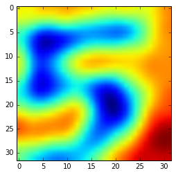

```python
imtrain = test_digits[0,:,:]

filter_imtrain = ndimage.gaussian_filter(imtrain, 1)
alpha = 30
sharpened = imtrain + alpha * (imtrain - filter_imtrain)
imtrain = ndimage.gaussian_filter(imtrain, 2)

plt.imshow(imtrain)
```

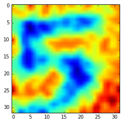

```python
imtrain = test_digits[0,:,:]

imtrain = ndimage.gaussian_filter(imtrain, 1)

plt.imshow(imtrain)
```

```python
image_size = 32

train_digits = np.reshape(train_digits,(-1, image_size, image_size)).astype(np.float32)
test_digits = np.reshape(test_digits,(-1, image_size, image_size)).astype(np.float32)
train_digit_labels = np.reshape(train_digit_labels,(-1))
test_digit_labels = np.reshape(test_digit_labels,(-1))

num_labels = 11

def reformat(labels):

  # Map 2 to [0.0, 1.0, 0.0 ...], 3 to [0.0, 0.0, 1.0 ...], 11 to [0.0, 0.0, ...]
    labels = (np.arange(1, num_labels) == labels[:,None]).astype(np.float32)
    return labels

train_digit_labels_hot = reformat(train_digit_labels)


test_digit_labels_hot = reformat(test_digit_labels)
print('Training set', train_digits.shape, train_digit_labels.shape, train_digit_labels_hot.shape)
print('Test set', test_digits.shape, test_digit_labels.shape, test_digit_labels_hot.shape)
```

[figure not shown]

[figure not shown]

```python
image_size = 32

def sharpen(dataset):
    rows = dataset.shape[0]
    datasharp = np.ndarray(shape=(rows, image_size, image_size),
                         dtype=np.float32)
    for i in range(rows):
        image = dataset[i, :, :]
        datasharp[i, :, :] = ndimage.gaussian_filter(image, 1)

    return datasharp

train_digits_s = sharpen(train_digits)
test_digits_s = sharpen(test_digits)
showDataImages(train_digits_s,5)
showDataImages(test_digits_s,5)
```

```python
%matplotlib inline
def showDataImages(dataset,n): # shows size of the sample

   # indices=np.random.choice(dataset.shape[0], n)
    fig=plt.figure()
    for i in range(n):
        a=fig.add_subplot(1,n,i+1)
        plt.imshow(dataset[i,:,:])
        # a.set_title(chr(labels[indices[i]]+ord('A')))
        a.axes.get_xaxis().set_visible(False)
        a.axes.get_yaxis().set_visible(False)
    plt.show()
```

```python
showDataImages(train_digits,5)
showDataImages(test_digits,5)
```

```python
with h5py.File('digits.h5', 'w') as hf:
    hf.create_dataset("train_digits",  data=train_digits)
    hf.create_dataset("train_digit_labels",  data=train_digit_labels)
    hf.create_dataset("train_digit_labels_hot",  data=train_digit_labels_hot)
    hf.create_dataset("test_digits",  data=test_digits)
    hf.create_dataset("test_digit_labels",  data=test_digit_labels)
    hf.create_dataset("test_digit_labels_hot",  data=test_digit_labels_hot)
```

```python
with h5py.File('digits.h5', 'r') as hf:
    train_digits = hf['train_digits'][:]
    train_digit_labels = hf['train_digit_labels'][:]
    train_digit_labels_hot = hf['train_digit_labels_hot'][:]
    test_digits = hf['test_digits'][:]
    test_digit_labels = hf['test_digit_labels'][:]
    test_digit_labels_hot = hf['test_digit_labels_hot'][:]
    showDataImages(train_digits, 5)
    print(train_digit_labels_hot[0:5,:])
    showDataImages(test_digits, 5)
    print(test_digit_labels_hot[0:5,:])
```

```
[[ 1.  0.  0.  0.  0.  0.  0.  0.  0.  0.  0.]
 [ 0.  0.  0.  0.  0.  0.  0.  0.  1.  0.  0.]
 [ 0.  0.  0.  0.  0.  0.  0.  0.  0.  0.  1.]
 [ 0.  0.  0.  0.  0.  0.  0.  0.  0.  0.  1.]
 [ 0.  0.  0.  0.  0.  0.  0.  0.  0.  0.  1.]]
```

```
[[ 0.  0.  0.  0.  1.  0.  0.  0.  0.  0.  0.]
 [ 0.  0.  0.  0.  0.  0.  0.  0.  0.  0.  1.]
 [ 0.  0.  0.  0.  0.  0.  0.  0.  0.  0.  1.]
 [ 0.  0.  0.  0.  0.  0.  0.  0.  0.  0.  1.]
 [ 0.  0.  0.  0.  0.  0.  0.  0.  0.  0.  1.]]
```

```python
image_size = 32
num_labels = 11

def reformat(dataset):
  dataset = dataset.reshape((-1, image_size * image_size)).astype(np.float32)
  # Map 2 to [0.0, 1.0, 0.0 ...], 3 to [0.0, 0.0, 1.0 ...]
 # labels = (np.arange(num_labels) == labels[:,None]).astype(np.float32)
  return dataset
train_digits = reformat(train_digits)

test_digits = reformat(test_digits)
print('Training set', train_digits.shape, train_digit_labels_hot.shape)

print('Test set', test_digits.shape, test_digit_labels_hot.shape)
```

[output not shown]

```python
def accuracy(predictions, labels):
  return (100.0 * np.sum(np.argmax(predictions, 1) == np.argmax(labels, 1))
          / predictions.shape[0])
def accuracy_seq(predictions, labels):
    a = 0
    s = predictions.shape[0]/5
    for i in range(s):
        a += ((np.sum(np.argmax(predictions[5*i:5*(i+1)], 1) == np.argmax(labels[5*i:5*(i+1)], 1)) >= 4.9))
    return 100.0 * a / s
```

```python
# Network Parameters
n_hidden_1 = 1024 # 1st layer num features
n_hidden_2 = 512 # 2nd layer num features
n_input = 1024 # SVHN data input (img shape: 32*32)
n_classes = 11 # SVHN total classes (0-9 digits + blank)
batch_size = 40
test_batch = 6530
p = 1e-5


graph = tf.Graph()
with graph.as_default():





    # tf Graph input
    tf_train_digits = tf.placeholder(tf.float32, shape=(batch_size, n_input))
    tf_train_digit_labels_hot = tf.placeholder(tf.float32, shape=(batch_size, n_classes))
    #tf_valid_dataset = tf.constant(valid_dataset)
    tf_test_digits = tf.constant(test_digits)

    # Create model
    def multilayer_perceptron(_X, _weights, _biases):
        layer_1 = tf.nn.relu(tf.add(tf.matmul(_X, _weights['h1']), _biases['b1'])) #Hidden layer with RELU activation
        layer_2 = tf.nn.relu(tf.add(tf.matmul(layer_1, _weights['h2']), _biases['b2'])) #Hidden layer with RELU activation
        return tf.matmul(layer_2, _weights['out']) + _biases['out']

    # Store layers weight & bias
    weights = {
        'h1': tf.Variable(tf.truncated_normal([n_input, n_hidden_1], stddev = 0.05)),
        'h2': tf.Variable(tf.truncated_normal([n_hidden_1, n_hidden_2], stddev = 0.05)),
        'out': tf.Variable(tf.truncated_normal([n_hidden_2, n_classes], stddev = 0.05))
    }
    biases = {
        'b1': tf.Variable(tf.zeros([n_hidden_1])),
        'b2': tf.Variable(tf.zeros([n_hidden_2])),
        'out': tf.Variable(tf.zeros([n_classes]))
    }

    regularizer = np.multiply(p, tf.nn.l2_loss(weights['h1']))


    # Construct model
    pred = multilayer_perceptron(tf_train_digits, weights, biases)

    # Define loss and optimizer
    loss = tf.reduce_mean(tf.nn.softmax_cross_entropy_with_logits(pred, tf_train_digit_labels_hot)) + regularizer# Softmax loss
    global_step = tf.Variable(0)  # count the number of steps taken.
    learning_rate = tf.train.exponential_decay(0.4, global_step, 1000, 0.65, staircase=True)
    optimizer = tf.train.GradientDescentOptimizer(learning_rate).minimize(loss, global_step=global_step)

     # Predictions for the training, validation, and test data.

    train_prediction = tf.nn.softmax(pred)
    #valid_prediction = tf.nn.softmax(multilayer_perceptron (tf_valid_dataset, weights, biases))

    test_prediction = tf.nn.softmax(multilayer_perceptron(tf_test_digits, weights, biases))
```

```python
num_steps = 4001

with tf.Session(graph=graph) as session:
  tf.initialize_all_variables().run()
  print("Initialized")
  for step in range(num_steps):
    # Pick an offset within the training data, which has been randomized.
    # Note: we could use better randomization across epochs.
    offset = (step * batch_size) % (train_digit_labels_hot.shape[0])
    # Generate a minibatch.
    batch_data = train_digits[offset:(offset + batch_size), :]
    batch_labels = train_digit_labels_hot[offset:(offset + batch_size), :]
    # Prepare a dictionary telling the session where to feed the minibatch.
    # The key of the dictionary is the placeholder node of the graph to be fed,
    # and the value is the numpy array to feed to it.
    feed_dict = {tf_train_digits : batch_data, tf_train_digit_labels_hot : batch_labels}
    _, l, predictions = session.run(
      [optimizer, loss, train_prediction], feed_dict=feed_dict)
    if (step % 200 == 0):
      print("Minibatch loss at step %d: %f" % (step, l))
      print("Minibatch accuracy: %.1f%%" % accuracy(predictions, batch_labels))
  a = 0
  b = 0
  for i in range(10):
    offset = (step * test_batch) % (test_digit_labels_hot.shape[0])
    test_data = test_digits[offset:(offset + test_batch), :]
    test_labels = test_digit_labels_hot[offset:(offset + test_batch), :]
    a += accuracy(test_prediction.eval(feed_dict={tf_test_digits:test_data}), test_labels)
    b += accuracy_seq(test_prediction.eval(feed_dict={tf_test_digits:test_data}), test_labels)
  a = a/10
  b = b/10
  print("Test accuracy: %.1f%%" % a)
  print("Test accuracy_seq: %.1f%%" % b)
```

```
Initialized
Minibatch loss at step 0: 2.436095
Minibatch accuracy: 5.0%
Minibatch loss at step 200: 0.627966
Minibatch accuracy: 77.5%
Minibatch loss at step 400: 0.872423
Minibatch accuracy: 72.5%
Minibatch loss at step 600: 1.144288
Minibatch accuracy: 62.5%
Minibatch loss at step 800: 0.505748
Minibatch accuracy: 85.0%
Minibatch loss at step 1000: 0.503641
Minibatch accuracy: 85.0%
Minibatch loss at step 1200: 0.374249
Minibatch accuracy: 95.0%
Minibatch loss at step 1400: 0.433388
Minibatch accuracy: 87.5%
Minibatch loss at step 1600: 0.571731
Minibatch accuracy: 85.0%
Minibatch loss at step 1800: 0.446818
Minibatch accuracy: 90.0%
Minibatch loss at step 2000: 0.253727
Minibatch accuracy: 90.0%
Minibatch loss at step 2200: 0.452897
Minibatch accuracy: 85.0%
Minibatch loss at step 2400: 0.188140
Minibatch accuracy: 90.0%
Minibatch loss at step 2600: 0.438614
Minibatch accuracy: 87.5%
Minibatch loss at step 2800: 0.358102
Minibatch accuracy: 90.0%
Minibatch loss at step 3000: 0.196992
Minibatch accuracy: 95.0%
Minibatch loss at step 3200: 0.483803
Minibatch accuracy: 85.0%
Minibatch loss at step 3400: 0.328483
Minibatch accuracy: 85.0%
Minibatch loss at step 3600: 0.356097
Minibatch accuracy: 85.0%
Minibatch loss at step 3800: 0.485175
Minibatch accuracy: 87.5%
Minibatch loss at step 4000: 0.501462
Minibatch accuracy: 85.0%
Test accuracy: 89.8%
Test accuracy_seq: 60.9%
```

### Question 4

*Describe how you set up the training and testing data for your model. How does the model perform on a realistic dataset?*

**Answer:**I used information from the bounding boxes to cut the images into individual digits. Then I rescaled all of the images to 32 by 32 pixels to run through the same models I used for the notMNIST data. On a larger test set than I previously had, my accuracy was ~.90 but the sequence accuracy was only 61%.

### Question 5

*What changes did you have to make, if any, to achieve "good" results? Were there any options you explored that made the results worse?*

**Answer:** I tried a gaussian filter which looked better to me but did not improve results. The relu network performed better than the LSTM as with the notMNIST data. The parameter adjustment with batch size did not make a large difference for the relu. I had previously experimented with the learning rate for the Deep Learning course to optimize performance.

### Question 6

*What were your initial and final results with testing on a realistic dataset? Do you believe your model is doing a good enough job at classifying numbers correctly?*

**Answer:**The LSTM only gave an 85% accuracy on individual digits and a 46% on full sequences. This was substantially improved with the relu as described in Question 4. I would need a large number of layers maybe in a convolution net to achieve the 96% accuracy on sequences of the published model. My model is not reliable, but I would need a more powerful computer to greatly improve the accuracy.

## Step 3: Test a Model on Newly-Captured Images

Take several pictures of numbers that you find around you (at least five), and run them through your classifier on your computer to produce example results. Alternatively (optionally), you can try using OpenCV / SimpleCV / Pygame to capture live images from a webcam and run those through your classifier.

### Implementation

Use the code cell (or multiple code cells, if necessary) to implement the first step of your project. Once you have completed your implementation and are satisfied with the results, be sure to thoroughly answer the questions that follow.

```python
### Your code implementation goes here.
### Feel free to use as many code cells as needed.

from __future__ import print_function
import matplotlib.pyplot as plt
import numpy as np
import os
import sys
import tarfile
import scipy.io as sio
import cv2

from IPython.display import display, Image
from scipy import ndimage, misc
#from sklearn.linear_model import LogisticRegression
from six.moves.urllib.request import urlretrieve
from six.moves import cPickle as pickle
import tensorflow as tf
from tensorflow.python.ops import rnn, rnn_cell
import h5py
```

```python
%matplotlib inline
def showDataImages(dataset,m,n): # shows size of the sample

   # indices=np.random.choice(dataset.shape[0], n)
    fig=plt.figure()
    for i in range(m,m+n):
        a=fig.add_subplot(1,n,i+1-m)
        plt.imshow(dataset[i, :, :])
        # a.set_title(chr(labels[indices[i]]+ord('A')))
        a.axes.get_xaxis().set_visible(False)
        a.axes.get_yaxis().set_visible(False)
    plt.show()
```

```python
imtest = ndimage.imread('photos/IMG_2870crop1.JPG')
misc.imsave('test.png', imtest)
test = ndimage.imread('test.png')
Image('test.png')
print(test.shape)
```

```
(24, 48, 3)
```

```python
####test methods

im = cv2.resize(cv2.imread('photos/IMG_0050crop.JPG'),(48,96))
im1 = cv2.imread('photos/IMG_0050crop.JPG')
'''
cv2.namedWindow('image', cv2.WINDOW_NORMAL)
cv2.imshow('image',im)
cv2.waitKey(0)
cv2.destroyAllWindows()
'''

imgray = cv2.cvtColor(im,cv2.COLOR_BGR2GRAY)
print (imgray.shape)
#imgray = (255 - imgray)
imgray1 = cv2.cvtColor(im1,cv2.COLOR_BGR2GRAY)
ret,thresh = cv2.threshold(imgray,100,255,0)
im2, contours, hierarchy = cv2.findContours(thresh,cv2.RETR_TREE,cv2.CHAIN_APPROX_SIMPLE)
print(len(contours))
'''
#cv2.drawContours(im2, contours, -1, (0,255,0), 3)
cv2.startWindowThread()
cv2.namedWindow('image', cv2.WINDOW_NORMAL)
cv2.imshow('image',im2)
cv2.waitKey(20000)
cv2.destroyAllWindows()

'''
boxes = []
areas = []
for i in range(0, len(contours)):
    #print(cv2.contourArea(contours[i],True))
    areas.append(cv2.contourArea(contours[i],True))
areas = np.array(areas)
#ind_areas = areas.argsort()[-5:][::-1]
ind_areas = areas.argsort()[::-1]
for i in range(len(contours)):
    j = ind_areas[i]
    cnt = contours[j]
       #mask = np.zeros(im2.shape,np.uint8)
       #cv2.drawContours(mask,[cnt],0,255,-1)
    x,y,w,h = cv2.boundingRect(cnt)
    boxes.append((x,y,w,h))
   # cv2.rectangle(im,(x,y),(x+w,y+h),(0,255,0),2)
   # digit = cv2.resize(imgray[y:y+h,x:x+w],(32,32))
   # digit = cv2.cvtColor(digit, cv2.COLOR_HSV2BGR)

 #   cv2.imshow('Features', digit)
  #  cv2.waitKey(1000)

     # cv2.imwrite(str(i)+'.png', im)
     #  digit = im[y:y+h,x:x+w]
boxes.sort()
print (ind_areas)
print (boxes[:5])
x,y,w,h = boxes[2]
print(boxes[2])
cv2.rectangle(imgray1,(x,y),(x+w,y+h),(0,255,0),2)
cv2.imshow('Features1', imgray1)
cv2.waitKey(10000)
cv2.destroyAllWindows()
```

```
(96, 48)
3
[2 1 0]
[(0, 0, 48, 96), (3, 13, 19, 73), (23, 1, 20, 75)]
(23, 1, 20, 75)
```

```
{'photos/IMG_0050crop.JPG': [(0, 0, 278, 278), (22, 41, 101, 205), (138, 3, 108, 215)]}
1
2
3
3
```

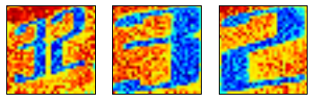

```
Enter a label for the image:11
Enter a label for the image:3
Enter a label for the image:2
Enter 1 for yes, 0 for no:1
```

```python
boxes = {}
image_size = 32  # Pixel width and height.
pixel_depth = 255.0  # Number of levels per pixel.


def get_boxes(boxes, image):
    if image not in boxes:
        boxes[image] = []
        imgray = cv2.imread(image, 0)
       # imgray = cv2.cvtColor(im,cv2.COLOR_BGR2GRAY)
        c = 0
        while c == 0:
            ret,thresh = cv2.threshold(imgray,100,255,0)
            im1, contours, hierarchy = cv2.findContours(thresh,cv2.RETR_TREE,cv2.CHAIN_APPROX_SIMPLE)
            #print (len(contours))
            if len(contours) < 2:
                c = 0
                imgray = (255 - imgray)
            else: c = 1
        for i in range(len(contours)):
            x,y,w,h = cv2.boundingRect(contours[i])
           #print (x,y,w,h)
            boxes[image].append((x,y,w,h))
            #if i < 5: print(boxes[image[i]])
        boxes[image].sort()
    return boxes


def get_image_digits(boxes,image):

    digits = []

    box_data = boxes[image]
    k = len(boxes[image])
    #print (k)
    #print (box_data[0])
    im = misc.imread(image, mode='P')
   # print(im.shape)
    for d in range(k):
        j = d + 1
        t = str(j)
        n = image.replace('.JPG', '') +'_'+t

        x = box_data[d][0]
        y = box_data[d][1]

        w = box_data[d][2]
        h = box_data[d][3]

        bottom = y + h
        right = x + w

        crop_dig = im[y:bottom, x:right]
       # print(crop_dig.shape)
        shape = crop_dig.shape
        if shape[0]*shape[1]==0 or w < .05*im.shape[0]: zoom_dig = ''
        else: zoom_dig = ndimage.interpolation.zoom(crop_dig, [32./shape[0], 32./shape[1]])
        name1 = n+'.png'
        if zoom_dig != '' :
            misc.imsave(name1, zoom_dig)

        digits.append(name1)
    l = len(digits)
   # if len(digits) < 5:
  #      digits.extend(['']*(5-l))

    return digits


def make_labels(boxes, image):

    dataset = np.ndarray(shape=(len(boxes[image]), image_size, image_size),
                                dtype=np.float32)
    #labels = np.ndarray(shape=(len(boxes[image])), dtype=np.int32)

    boxes = get_boxes(boxes, image)
    digits = get_image_digits(boxes, image)
   # print(len(digits))
    image_index = 0
    for i in range(len(digits)):
       # print (digits[i])
        try:

            image_data = (ndimage.imread(digits[i]).astype(float) -
                        pixel_depth / 2) / pixel_depth
            if image_data.shape != (image_size, image_size):
                raise Exception('Unexpected image shape: %s' % str(image_data.shape))
            dataset[image_index, :, :] = image_data
            image_index +=1
            print(image_index)
        except IOError as e:
            print('Could not read:', digits[i], ':', e, '- it\'s ok, skipping.')
           # dataset[i, :,:] = 0
           # image_index +=1

    num_images = image_index
    print(num_images)
    dataset = dataset[0:num_images, :, :]

    n = num_images/5
    r = num_images%5

    fig=plt.figure()
    for i in range(n):
        for j in range(5):
            a=fig.add_subplot(n,5,i*5+j+1)
            plt.imshow(dataset[i*5+j, :, :])
        # a.set_title(chr(labels[indices[i]]+ord('A')))
            a.axes.get_xaxis().set_visible(False)
            a.axes.get_yaxis().set_visible(False)
    plt.show()

    if r > 0:
        showDataImages(dataset,num_images-r,r)

    okay = 0
    while okay == 0 :
        i_labels = []
        for i in range(num_images):
            lab = (input('Enter a label for the image:'))
            i_labels.append(lab)
        okay = (input('Enter 1 for yes, 0 for no:'))

   # print (i_labels)
    labels = np.array(i_labels)
  #  print(labels)
    for f in os.listdir("./photos"):
        g = 'photos/' + f
        if g.endswith(".png"):os.remove(g)
    labels = labels[0:num_images]
    return dataset, labels
   # showDataImages(dataset, 0, num_images)






image = 'photos/IMG_0050crop.JPG'
Image(image)
boxes = get_boxes(boxes, image)
print (boxes)
digits = get_image_digits(boxes, image)
#for b in boxes[image]:print(b)
#for i in digits:print(i)
#Image(digits[1])
datatest, labelstest = make_labels(boxes, image)
```

```
0 IMG_2870crop1.JPG
1
2
Could not read: ./photos/IMG_2870crop1_3.png : [Errno 2] No such file or directory: './photos/IMG_2870crop1_3.png' - it's ok, skipping.
3
4
5
6
7
8
8
```

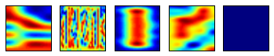

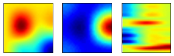

[output not shown]

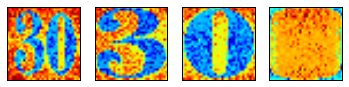

[output not shown]

[output cut: 460 more lines]

[output not shown]

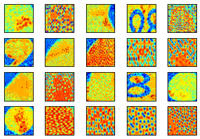

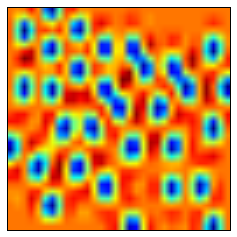

```
Enter a label for the image:11
Enter a label for the image:11
Enter a label for the image:11
Enter a label for the image:11
Enter a label for the image:11
Enter a label for the image:11
Enter a label for the image:11
Enter a label for the image:11
Enter a label for the image:11
Enter a label for the image:11
Enter a label for the image:11
Enter a label for the image:11
Enter a label for the image:11
Enter a label for the image:8
Enter a label for the image:11
Enter a label for the image:11
Enter a label for the image:11
Enter a label for the image:11
Enter a label for the image:11
Enter a label for the image:11
Enter a label for the image:11
Enter 1 for yes, 0 for no:1
3 IMG_2868crop.JPG
1
2
3
4
5
6
7
Could not read: ./photos/IMG_2868crop_8.png : [Errno 2] No such file or directory: './photos/IMG_2868crop_8.png' - it's ok, skipping.
7
```

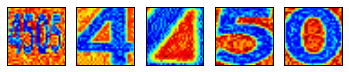

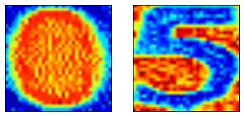

```
Enter a label for the image:11
Enter a label for the image:4
Enter a label for the image:11
Enter a label for the image:5
Enter a label for the image:10
Enter a label for the image:11
Enter a label for the image:5
Enter 1 for yes, 0 for no:1
4 IMG_2870crop.JPG
1
2
3
4
5
6
7
8
9
10
10
```

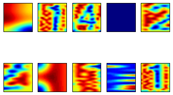

[output not shown]

[output cut: 132 more lines]

[output not shown]

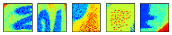

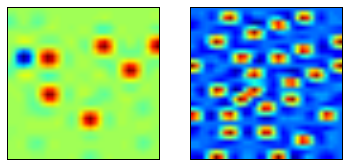

```
Enter a label for the image:2
Enter a label for the image:11
Enter a label for the image:11
Enter a label for the image:11
Enter a label for the image:11
Enter a label for the image:11
Enter a label for the image:11
Enter 1 for yes, 0 for no:1
6 IMG_2866crop.JPG
1
2
3
4
Could not read: ./photos/IMG_2866crop_5.png : [Errno 2] No such file or directory: './photos/IMG_2866crop_5.png' - it's ok, skipping.
5
Could not read: ./photos/IMG_2866crop_7.png : [Errno 2] No such file or directory: './photos/IMG_2866crop_7.png' - it's ok, skipping.
6
7
8
Could not read: ./photos/IMG_2866crop_11.png : [Errno 2] No such file or directory: './photos/IMG_2866crop_11.png' - it's ok, skipping.
8
```

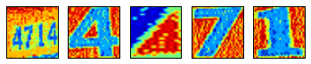

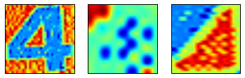

[output not shown]

[output cut: 63 more lines]

[output not shown]

[24 more figures not shown]

```
[ 1 11 11 11 11]
```

```python
def refine_data(pdata, plabels):
    data, labels = [], []
    zero = np.zeros(shape=(32, 32), dtype=np.float32)
    for i in range(plabels.shape[0]):
       # print(plabels.shape)
        if plabels[i]!=11:
            data.append(pdata[i])
            labels.append(plabels[i])

    if len(labels) < 5:
        data.extend([zero]*(5-len(labels)))
        labels.extend([11]*(5-len(labels)))
    return data, labels

def make_dataset(folder, boxes):
    dataset = np.ndarray(shape=(len(folder)*5, image_size, image_size),
                                dtype=np.float32)
    labels = np.ndarray(shape=(len(folder)*5), dtype=np.int32)
    for j, image in enumerate(folder):
        print(j,image)
        boxes = get_boxes(boxes, f+image)
        pdata, plabels = make_labels(boxes, f+image)
        data, lab = refine_data(pdata, plabels)
        for i in range(len(lab)):
            dataset[5*j+i,:,:] = data[i]
            labels[5*j+i] = lab[i]

    dataset = dataset[0:5*j, :, :]
    labels = labels[0:5*j]
    print('Full dataset tensor:', dataset.shape)
    print('Mean:', np.mean(dataset))
    print('Standard deviation:', np.std(dataset))
    print('Full labels tensor:', labels.shape)
    return dataset, labels

f = './photos/'
photos =os.listdir('./photos/')
phototest, labelstest = make_dataset(photos, boxes)
showDataImages(phototest, 0, 5)
print(labelstest[0:5])
```

```python
image_size = 32


num_labels = 12

def reformat(labels):

  # Map 2 to [0.0, 1.0, 0.0 ...], 3 to [0.0, 0.0, 1.0 ...], 11 to [0.0, 0.0, ...]
    labels = (np.arange(1, num_labels) == labels[:,None]).astype(np.float32)
    return labels

labelstest_hot = reformat(labelstest)



#print('Training set', train_digits.shape, train_digit_labels.shape, train_digit_labels_hot.shape)
print('Test set', phototest.shape, labelstest.shape, labelstest_hot.shape)
```

```
Test set (100, 32, 32) (100,) (100, 11)
```

```python
with h5py.File('photos.h5', 'w') as hf:
    hf.create_dataset("phototest",  data=phototest)
    hf.create_dataset("labelstest",  data=labelstest)
    hf.create_dataset("labelstest_hot",  data=labelstest_hot)
```

```
[ 1  9 11 11 11]
[[ 1.  0.  0.  0.  0.  0.  0.  0.  0.  0.  0.]
 [ 0.  0.  0.  0.  0.  0.  0.  0.  1.  0.  0.]
 [ 0.  0.  0.  0.  0.  0.  0.  0.  0.  0.  1.]
 [ 0.  0.  0.  0.  0.  0.  0.  0.  0.  0.  1.]
 [ 0.  0.  0.  0.  0.  0.  0.  0.  0.  0.  1.]]
```

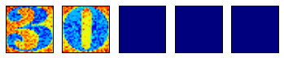

```
[ 1 11 11 11 11]
[[ 0.  0.  1.  0.  0.  0.  0.  0.  0.  0.  0.]
 [ 0.  0.  0.  0.  0.  0.  0.  0.  0.  1.  0.]
 [ 0.  0.  0.  0.  0.  0.  0.  0.  0.  0.  1.]
 [ 0.  0.  0.  0.  0.  0.  0.  0.  0.  0.  1.]
 [ 0.  0.  0.  0.  0.  0.  0.  0.  0.  0.  1.]]
```

```python
with h5py.File('digits.h5', 'r') as hf:
    train_digits = hf['train_digits'][:]
    train_digit_labels = hf['train_digit_labels'][:]
    train_digit_labels_hot = hf['train_digit_labels_hot'][:]

with h5py.File('photos.h5', 'r') as hg:
    phototest = hg['phototest'][:]
    labelstest = hg['labelstest'][:]
    labelstest_hot = hg['labelstest_hot'][:]

showDataImages(train_digits, 0, 5)
print(train_digit_labels[0:5])
print(train_digit_labels_hot[0:5, :])
showDataImages(phototest, 5, 5)
print(labelstest[0:5])
print(labelstest_hot[5:10, :])
```

```python
for i in range(len(0,20, 5)):
    showDataImages(phototest, i, 5)
    print(labelstest[i:5+i])
    print(labelstest_hot[i:5+i, :])
```

```python
f = h5py.File('photos.h5', 'r')
print ( f.keys())
print (train_digits.shape)
```

```
[u'labelstest', u'labelstest_hot', u'phototest']
(167010, 32, 32)
```

```python
image_size = 32
num_labels = 11

def reformat(dataset):
  dataset = dataset.reshape((-1, image_size * image_size)).astype(np.float32)
  # Map 2 to [0.0, 1.0, 0.0 ...], 3 to [0.0, 0.0, 1.0 ...]
 # labels = (np.arange(num_labels) == labels[:,None]).astype(np.float32)
  return dataset
train_digits = reformat(train_digits)
phototest = reformat(phototest)
print('Training set', train_digits.shape, train_digit_labels_hot.shape)

print('Test set', phototest.shape, labelstest_hot.shape)
```

```
Training set (167010, 1024) (167010, 11)
Test set (100, 1024) (100, 11)
```

```python
def accuracy(predictions, labels):
  return (100.0 * np.sum(np.argmax(predictions, 1) == np.argmax(labels, 1))
          / predictions.shape[0])
def accuracy_seq(predictions, labels):
    a = 0
    s = predictions.shape[0]/5
    for i in range(s):
        a += ((np.sum(np.argmax(predictions[5*i:5*(i+1)], 1) == np.argmax(labels[5*i:5*(i+1)], 1)) >= 4.9))
    return 100.0 * a / s
```

```python
# Network Parameters
n_hidden_1 = 1024 # 1st layer num features
n_hidden_2 = 512 # 2nd layer num features
n_input = 1024 # SVHN data input (img shape: 32*32)
n_classes = 11 # SVHN total classes (0-9 digits + blank)
batch_size = 40
test_batch = 100
p = 1e-5


graph = tf.Graph()
with graph.as_default():





    # tf Graph input
    tf_train_digits = tf.placeholder(tf.float32, shape=(batch_size, n_input))
    tf_train_digit_labels_hot = tf.placeholder(tf.float32, shape=(batch_size, n_classes))
    #tf_valid_dataset = tf.constant(valid_dataset)
    tf_phototest = tf.constant(phototest)

    # Create model
    def multilayer_perceptron(_X, _weights, _biases):
        layer_1 = tf.nn.relu(tf.add(tf.matmul(_X, _weights['h1']), _biases['b1'])) #Hidden layer with RELU activation
        layer_2 = tf.nn.relu(tf.add(tf.matmul(layer_1, _weights['h2']), _biases['b2'])) #Hidden layer with RELU activation
        return tf.matmul(layer_2, _weights['out']) + _biases['out']

    # Store layers weight & bias
    weights = {
        'h1': tf.Variable(tf.truncated_normal([n_input, n_hidden_1], stddev = 0.05)),
        'h2': tf.Variable(tf.truncated_normal([n_hidden_1, n_hidden_2], stddev = 0.05)),
        'out': tf.Variable(tf.truncated_normal([n_hidden_2, n_classes], stddev = 0.05))
    }
    biases = {
        'b1': tf.Variable(tf.zeros([n_hidden_1])),
        'b2': tf.Variable(tf.zeros([n_hidden_2])),
        'out': tf.Variable(tf.zeros([n_classes]))
    }

    regularizer = np.multiply(p, tf.nn.l2_loss(weights['h1']))


    # Construct model
    pred = multilayer_perceptron(tf_train_digits, weights, biases)

    # Define loss and optimizer
    loss = tf.reduce_mean(tf.nn.softmax_cross_entropy_with_logits(pred, tf_train_digit_labels_hot)) + regularizer# Softmax loss
    global_step = tf.Variable(0)  # count the number of steps taken.
    learning_rate = tf.train.exponential_decay(0.4, global_step, 1000, 0.65, staircase=True)
    optimizer = tf.train.GradientDescentOptimizer(learning_rate).minimize(loss, global_step=global_step)

     # Predictions for the training, validation, and test data.

    train_prediction = tf.nn.softmax(pred)
    #valid_prediction = tf.nn.softmax(multilayer_perceptron (tf_valid_dataset, weights, biases))

    test_prediction = tf.nn.softmax(multilayer_perceptron(tf_phototest, weights, biases))
```

```python
num_steps = 4001

with tf.Session(graph=graph) as session:
  tf.initialize_all_variables().run()
  print("Initialized")
  for step in range(num_steps):
    # Pick an offset within the training data, which has been randomized.
    # Note: we could use better randomization across epochs.
    offset = (step * batch_size) % (train_digit_labels_hot.shape[0])
    # Generate a minibatch.
    batch_data = train_digits[offset:(offset + batch_size), :]
    batch_labels = train_digit_labels_hot[offset:(offset + batch_size), :]
    # Prepare a dictionary telling the session where to feed the minibatch.
    # The key of the dictionary is the placeholder node of the graph to be fed,
    # and the value is the numpy array to feed to it.
    feed_dict = {tf_train_digits : batch_data, tf_train_digit_labels_hot : batch_labels}
    _, l, predictions = session.run(
      [optimizer, loss, train_prediction], feed_dict=feed_dict)
    if (step % 200 == 0):
      print("Minibatch loss at step %d: %f" % (step, l))
      print("Minibatch accuracy: %.1f%%" % accuracy(predictions, batch_labels))
  a = 0
  b = 0
  for i in range(10):
    offset = (step * test_batch) % (labelstest_hot.shape[0])
    test_data = phototest[offset:(offset + test_batch), :]
    test_labels = labelstest_hot[offset:(offset + test_batch), :]
    a += accuracy(test_prediction.eval(feed_dict={tf_phototest:test_data}), test_labels)
    b += accuracy_seq(test_prediction.eval(feed_dict={tf_phototest:test_data}), test_labels)
  a = a/10
  b = b/10
  print("Test accuracy: %.1f%%" % a)
  print("Test accuracy_seq: %.1f%%" % b)
```

```
Initialized
Minibatch loss at step 0: 2.415685
Minibatch accuracy: 5.0%
Minibatch loss at step 200: 0.650837
Minibatch accuracy: 82.5%
Minibatch loss at step 400: 0.934309
Minibatch accuracy: 72.5%
Minibatch loss at step 600: 1.079069
Minibatch accuracy: 62.5%
Minibatch loss at step 800: 0.531639
Minibatch accuracy: 82.5%
Minibatch loss at step 1000: 0.526556
Minibatch accuracy: 85.0%
Minibatch loss at step 1200: 0.426032
Minibatch accuracy: 90.0%
Minibatch loss at step 1400: 0.425747
Minibatch accuracy: 87.5%
Minibatch loss at step 1600: 0.566076
Minibatch accuracy: 85.0%
Minibatch loss at step 1800: 0.445013
Minibatch accuracy: 85.0%
Minibatch loss at step 2000: 0.268812
Minibatch accuracy: 90.0%
Minibatch loss at step 2200: 0.448401
Minibatch accuracy: 82.5%
Minibatch loss at step 2400: 0.208626
Minibatch accuracy: 90.0%
Minibatch loss at step 2600: 0.424200
Minibatch accuracy: 87.5%
Minibatch loss at step 2800: 0.330964
Minibatch accuracy: 92.5%
Minibatch loss at step 3000: 0.211939
Minibatch accuracy: 97.5%
Minibatch loss at step 3200: 0.478885
Minibatch accuracy: 85.0%
Minibatch loss at step 3400: 0.308279
Minibatch accuracy: 90.0%
Minibatch loss at step 3600: 0.382305
Minibatch accuracy: 87.5%
Minibatch loss at step 3800: 0.458217
Minibatch accuracy: 87.5%
Minibatch loss at step 4000: 0.501895
Minibatch accuracy: 85.0%
Test accuracy: 93.0%
Test accuracy_seq: 75.0%
```

# Question 7

*Choose five candidate images of numbers you took from around you and provide them in the report. Are there any particular qualities of the image(s) that might make classification difficult?*

```python
Image('photos/IMG_2870crop1.JPG')
```

```python
Image('photos/IMG_2745crop.JPG')
```

```python
Image('photos/IMG_0052crop.JPG')
```

[figure not shown]

```python
Image('photos/IMG_2874crop.JPG')
```

```python
Image('photos/IMG_2865crop.JPG')
```

**Answer:**Since I don't have a camera, these photos were sent to me by family members. In some cases the photos are blurry, numbers are at different angles, there is a mixture of light and dark digits, and the photo IMG_0052crop.JPG does not show up in this format.

### Question 8

*Is your model able to perform equally well on captured pictures or a live camera stream when compared to testing on the realistic dataset?*

### Optional: Question 9

*If necessary, provide documentation for how an interface was built for your model to load and classify newly-acquired images.*

**Answer:** I described the interface above. See also the make_dataset function above.

### Step 4: Explore an Improvement for a Model

There are many things you can do once you have the basic classifier in place. One example would be to also localize where the numbers are on the image. The SVHN dataset provides bounding boxes that you can tune to train a localizer. Train a regression loss to the coordinates of the bounding box, and then test it.

### Implementation

Use the code cell (or multiple code cells, if necessary) to implement the first step of your project. Once you have completed your implementation and are satisfied with the results, be sure to thoroughly answer the questions that follow.

```python
### Your code implementation goes here.
### Feel free to use as many code cells as needed.
```

### Question 10

*How well does your model localize numbers on the testing set from the realistic dataset? Do your classification results change at all with localization included?*

**Answer:**

### Question 11

*Test the localization function on the images you captured in **Step 3**. Does the model accurately calculate a bounding box for the numbers in the images you found? If you did not use a graphical interface, you may need to investigate the bounding boxes by hand.* Provide an example of the localization created on a captured image.

**Answer:**

## Optional Step 5: Build an Application or Program for a Model

Take your project one step further. If you're interested, look to build an Android application or even a more robust Python program that can interface with input images and display the classified numbers and even the bounding boxes. You can for example try to build an augmented reality app by overlaying your answer on the image like the [Word Lens](https://en.wikipedia.org/wiki/Word_Lens) app does.

Loading a TensorFlow model into a camera app on Android is demonstrated in the [TensorFlow Android demo app](https://github.com/tensorflow/tensorflow/tree/master/tensorflow/examples/android), which you can simply modify.

If you decide to explore this optional route, be sure to document your interface and implementation, along with significant results you find. You can see the additional rubric items that you could be evaluated on by [following this link](https://review.udacity.com/#!/rubrics/413/view).

### Optional Implementation

Use the code cell (or multiple code cells, if necessary) to implement the first step of your project. Once you have completed your implementation and are satisfied with the results, be sure to thoroughly answer the questions that follow.

```python
### Your optional code implementation goes here.
### Feel free to use as many code cells as needed.
```

### Documentation

Provide additional documentation sufficient for detailing the implementation of the Android application or Python program for visualizing the classification of numbers in images. It should be clear how the program or application works. Demonstrations should be provided.

*Write your documentation here.*

> **Note**: Once you have completed all of the code implementations and successfully answered each question above, you may finalize your work by exporting the iPython Notebook as an HTML document. You can do this by using the menu above and navigating to  
> **File -> Download as -> HTML (.html)**. Include the finished document along with this notebook as your submission.